# PracowniaSpecBioinf

### Programowanie dynamiczne

#### Subproblemy

1 + 2 + 3 + 4 = (1 + 2) + (3 + 4) = 3 + 7 = 10

#### Dziel i zwyciężaj

- Dzielimy wyjściowy problem na subproblemy tego samego typu
- Rozwiązujemy podproblemy rekurencyjnie
- Rozwiązujemy wyjściowy problem w oparciu o rozwiązania podproblemów

```python
#Rekurencja

def Fib(n):
    if n == 1 or n == 2:
        return 1
    else:
        return Fib(n-1)+Fib(n-2)

print(Fib(4)) #1, 1, 2, 3,....
```

```
3
```

#### Jakie są wady takiego podejścia?

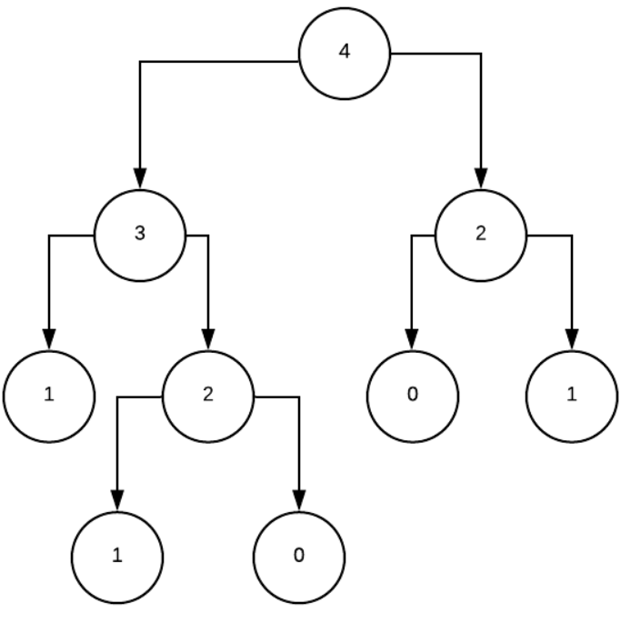

```python
from IPython.display import Image
Image(filename="fib.png")
```

W programowaniu dynamicznym nie liczymy tych samych rzeczy wielokrotnie!

```python
#Programowanie dynamiczne

def Fib2(n):
    numbers = [0]*n
    numbers[0], numbers[1] = 1, 1
    for i in range(2, n):
        numbers[i] = numbers[i-1] + numbers[i-2]
    return numbers[-1]

print(Fib2(4))
```

```
3
```

#### Najdłuższy wspólny podciąg (LCS)

Dane są dwa ciągi $s_1s_2...s_n$ oraz $p_1p_1...p_m$, gdzie $n$ i $m$ to długość pierwszego i drugiego słowa odpowiednio. Cel: znaleźć podciąg symboli obecnych w obu ciągach.

```python
def lcs(X, Y):
    import numpy as np
    import pandas as pd
    m = len(X)
    n = len(Y)

    L = np.zeros((m+1,n+1))

    for i in range(m + 1):
        for j in range(n + 1):
            if i == 0 or j == 0 :
                continue
            elif X[i-1] == Y[j-1]:
                L[i,j] = L[i-1,j-1]+1
            else:
                L[i,j] = max(L[i-1,j], L[i,j-1])

    df = pd.DataFrame(L, columns = ['-']+list(s2), index = ['-']+list(s1))
    print(df)

    return L[m,n]



s1 = "AATGCA"
s2 = "CATTTTC"

print(lcs(s1,s2))
```

```
     -    C    A    T    T    T    T    C
-  0.0  0.0  0.0  0.0  0.0  0.0  0.0  0.0
A  0.0  0.0  1.0  1.0  1.0  1.0  1.0  1.0
A  0.0  0.0  1.0  1.0  1.0  1.0  1.0  1.0
T  0.0  0.0  1.0  2.0  2.0  2.0  2.0  2.0
G  0.0  0.0  1.0  2.0  2.0  2.0  2.0  2.0
C  0.0  1.0  1.0  2.0  2.0  2.0  2.0  3.0
A  0.0  1.0  2.0  2.0  2.0  2.0  2.0  3.0
3.0
```

#### Zadanie: Jak powyższe rozwiązanie wyglądałoby w wersji rekurencyjnej?

```python
def lcs(X, Y):
    import numpy as np
    m = len(X)
    n = len(Y)

    L = np.zeros((m+1,n+1))

    for i in range(m + 1):
        for j in range(n + 1):
            if i == 0 or j == 0 :
                continue
            elif X[i-1] == Y[j-1]:
                L[i,j] = L[i-1,j-1]+1
            else:
                L[i,j] = max(L[i-1,j], L[i,j-1])


    ile= int(L[m,n])


    lcs = [""] * (ile+1)

    #zaczynay od prawego dolnego rogu
    i = m
    j = n
    while i > 0 and j > 0:

        #jak są te same znaki w X i  Y
        if X[i-1] == Y[j-1]:
            lcs[ile-1] = X[i-1]
            i-=1
            j-=1
            ile-=1

        #Jak nie te same: case1
        elif L[i-1][j] > L[i][j-1]:
            i-=1
        #Jak nie te same: case2
        else:
            j-=1

    return "".join(lcs)

s1 = "AATGCAAA"
s2 = "CATTTTCG"


print(lcs(s1,s2))
```

```
ATC
```

#### Problem plecakowy

Danych jest $n$ przedmiotów, gdzie każdy z nich ma pewną wartość $v_i$ oraz wagę $w_i$, a zatem formalnie dwie listy $[v_1,v_2,...,v_n]$ oraz $[w_1,w_2,...,w_n]$. Ponadto zakładamy pewną wartość maksymalnej wagi $W$. Problem: jak wybrać przedmioty, aby ich łączna masa nie przekoczyła $W$, a które równocześnie są najbardziej cenne.

Niech $K[i,w]$ oznacza największą możliwą wartość przy założeniu łącznej wagi co najwyżej $w$ oraz wykorzystaniu $i$ pierwszych elementów (czyli 0,1,2,...,i-1). Wtedy oczywiście $K[0,w] = K[i,0] = 0$. To są nasze warunki brzegowe.

#### Rozwiązanie1: Brutalna siła

```python
#Jak wygenerowac wszystkie kombinacje?

import itertools

x = [1,2,3,4]
kombinacje = []
for i in range(1,len(x)+1):
    kombinacje += list(itertools.combinations(x,i))

print(kombinacje)
```

```
[(1,), (2,), (3,), (4,), (1, 2), (1, 3), (1, 4), (2, 3), (2, 4), (3, 4), (1, 2, 3), (1, 2, 4), (1, 3, 4), (2, 3, 4), (1, 2, 3, 4)]
```

```python
def Brutalny_plecak(W, wartosci, wagi):

    ww = dict(zip(wagi,wartosci))
    n = len(wagi)
    kombinacje_wag = []

    for i in range(1, n+1):
        kombinacje_wag += list(itertools.combinations(wagi,i))

    wartosc = 0
    for k in kombinacje_wag:
        if sum(k) <= W:
            k = [ww[w] for w in k]
            if sum(k) > wartosc:
                koszyk = k
    return koszyk
```

```python
wartosci = [60, 100, 120, 100, 100]
wagi = [10, 20, 30, 20, 20]
W = 70

print(Brutalny_plecak(W, wartosci, wagi))
```

```
[60, 100, 100, 100]
```

```python
wartosci = [60, 100, 120, 100, 100]
wagi = [10, 20, 30, 20, 20]
W = 60

print(Brutalny_plecak(W, wartosci, wagi))
```

```
[100, 100, 100]
```

#### Rozwiązanie2: Algorytm zachłanny

```python
def ZachlannyPlecak(W, wartosci, wagi):
    ww = list(zip(wartosci, wagi)) #lista krotek (wartosci, wagi)
    ww = sorted(ww, key = lambda x: x[0], reverse = True) #sortuje list wg wag od najwiekszej do najmniejszej (reverse=True)
    plecak = []
    for elem in ww:
        if elem[1] <= W:
            plecak.append(elem[0])
            W -= elem[1]
    return plecak


wartosci = [60, 100, 120, 100, 100]
wagi = [10, 20, 30, 20, 20]
W = 70

print(ZachlannyPlecak(W, wartosci, wagi))
```

```
[120, 100, 100]
```

```python
wartosci = [60, 100, 120, 100, 100]
wagi = [10, 20, 30, 20, 20]
W = 60

print(ZachlannyPlecak(W, wartosci, wagi))
```

```
[120, 100, 60]
```

#### Rozwiązanie3: Rozwiązanie dynamiczne

```python
def Plecak(W, wt, val, n):

    import numpy as np
    K = np.zeros((n+1,W+1))

    for i in range(n + 1):
        for w in range(W + 1):
            if i == 0 or w == 0:
                continue
            elif wt[i-1] <= w: #jezeli waga i-tego przedmiotu jest mniejsza od zakładanej wagi
                K[i,w] = max(K[i-1,w], val[i-1]+ K[i-1,w-wt[i-1]])
            else:  #jeżeli waga i-1-tego produktu przekracza zakładaną wage w
                K[i,w] = K[i-1,w]
    full = K[n,W]
    print("Laczna wartosc: ", full)

    w = W

    for i in range(n, 0, -1):
        if full <= 0:
            break
        if full == K[i - 1,w]:
            continue
        else:
            print(val[i - 1])
            full = full - val[i - 1]
            w = w - wt[i - 1]
```

```python
n = 5
wartosci = [60, 100, 120, 100, 100]
wagi = [10, 20, 30, 20, 20]
W = 70

print(Plecak(W, wagi, wartosci, n))
```

```
Laczna wartosc:  360.0
100
100
100
60
None
```

#### Zadanie: Problem wydawania reszty: Jak wydać zadaną kwotę przy najmniejszej ilości monet? Zaproponuj trzy rozwiązania: brutalne, zachłanne i dynamiczne. Wejściem powinna być lista możliwych nominałów oraz założona kwota, wyjściem - wybrane nominały.

```python
wartosci = [60, 100, 120, 100, 100]
wagi = [10, 20, 30, 20, 20]
W = 70
n = 3

print(Plecak(W, wagi, wartosci, n))
```

```
Laczna wartosc:  280.0
120
100
60
None
```

### Gdzie programowanie dynamiczne pojawia się w bioinformatyce?

- algorytm Needlemana-Wunscha (globalne dopasowanie sekwencji)
- algorytm Smitha-Watermana (lokalne dopasowanie sekwencji)
- algorytm Nussinova (drugorzędowa strukutra RNA)

```python
def SequenceAlign(seqA, seqB, similarityMatrix, insert=8, extend=4):

    import numpy as np
    import pandas as pd

    numI = len(seqA) + 1
    numJ = len(seqB) + 1

    SMatrix = np.zeros((numI, numJ))
    RMatrix = np.zeros((numI, numJ))

    for i in range(1, numI):
        RMatrix[i, 0] = 1

    for j in range(1, numJ):
        RMatrix[0, j] = 2

    for i in range(1, numI):
        for j in range(1, numJ):

            penalty1 = insert
            penalty2 = insert

            if RMatrix[i-1, j] == 1:
                penalty1 = extend

            elif RMatrix[i, j-1] == 2:
                penalty2 = extend

            similarity = similarityMatrix[seqA[i-1]][seqB[j-1]]

            paths = [SMatrix[i-1, j-1] + similarity,
                     SMatrix[i-1, j] - penalty1,
                     SMatrix[i, j-1] - penalty2]

            best = max(paths)
            route = paths.index(best)

            SMatrix[i, j] = best
            RMatrix[i, j] = route

        alignA = []
        alignB = []

        i = numI-1
        j = numJ-1

        score = SMatrix[i, j]

        while i > 0 or j > 0:
            route = RMatrix[i, j]

            if route == 0:
                alignA.append( seqA[i-1] )
                alignB.append( seqB[j-1] )
                i -= 1
                j -= 1

            elif route == 1:
                alignA.append( seqA[i-1] )
                alignB.append( '-' )
                i -= 1

            elif route == 2:
                alignA.append( '-' )
                alignB.append( seqB[j-1] )
                j -= 1

    df = pd.DataFrame(SMatrix, columns = ['-']+list(seqB), index = ['-']+list(seqA))
    print(df)

    alignA.reverse()
    alignB.reverse()

    alignA = ''.join(alignA)
    alignB = ''.join(alignB)

    return score, alignA, alignB


seqA = "CAATCAT"
seqB = "CAATGCCT"

DNA_m = {'G': { 'G':2, 'C': -3, 'A':-3, 'T':-3 },
'C': { 'G': -3, 'C':2, 'A':-3, 'T':-3 },
'A': { 'G':-3, 'C':-3, 'A':2, 'T': -3 },
'T': { 'G':-3, 'C':-3, 'A':-3, 'T':2 }}

score, alignA, alignB = SequenceAlign(seqA, seqB, DNA_m, insert=4, extend=2)

print(score)
print(alignA)
print(alignB)
```

```
     -    C    A    A    T    G    C    C    T
-  0.0  0.0  0.0  0.0  0.0  0.0  0.0  0.0  0.0
C  0.0  2.0 -2.0 -3.0 -3.0 -3.0  2.0  2.0 -2.0
A  0.0 -2.0  4.0  0.0 -4.0 -6.0 -2.0 -1.0 -1.0
A  0.0 -3.0  0.0  6.0  2.0  0.0 -4.0 -5.0 -4.0
T  0.0 -3.0 -4.0  2.0  8.0  4.0  0.0 -2.0 -3.0
C  0.0  2.0 -2.0  0.0  4.0  5.0  6.0  2.0 -2.0
A  0.0 -2.0  4.0  0.0  2.0  1.0  2.0  3.0 -1.0
T  0.0 -3.0  0.0  1.0  2.0 -1.0 -2.0 -1.0  5.0
5.0
CAAT-CAT
CAATGCCT
```

### Uzupełnienie: Problemy P i NP

```python
x = [78, -52, -72, -78, -1, 48, -16, 79, 51, -22, 8, -31, 93, 58, -80, -14, -44, -38, -49, 17, -52, -82, 93, -71, 89, 32, 13, 18]
print(x)
```

```
[78, -52, -72, -78, -1, 48, -16, 79, 51, -22, 8, -31, 93, 58, -80, -14, -44, -38, -49, 17, -52, -82, 93, -71, 89, 32, 13, 18]
```

##### Pytanie1: Czy na liście $x$ znajduje sie liczba 40?

##### Pytanie2: Czy na liście $x$ są dwie liczby które sumują się do 30?

##### Pytanie3: Czy na liście $x$ są trzy liczby które sumują się do 30?

##### Pytanie4: Czy na liście $x$ moge wybrać jakiś podzbiór liczb które sumują się do 30?

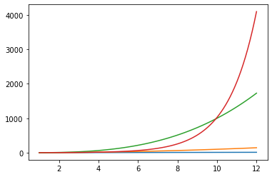

```python
import numpy as np
import matplotlib.pyplot as plt

n = np.linspace(1,12,100)
y1 = n
y2 = n**2
y3 = n**3
y4 = 2**n #rosnie bardzo szybko

plt.plot(n,y1)
plt.plot(n,y2)
plt.plot(n,y3)
plt.plot(n,y4)
plt.show()
```

Problem jest ypu $P$ jeżeli istnieje rozwiązanie w czasie wielomianowym, z kolei problem $NP$ to taki problem którego rozwiązanie można zweryfikować w czasie wielomianowym.

Oczywiście $P \subset NP$. Pytanie za 1 mld dolarów: Czy $P = NP$?.